# Impact of covid-19 in mobility

Mohammed ElBelbesy, Mat:00801592

## Overview

### Abstract

COVID-19 is a pandemic disease that has wreaked havoc in all countries all over the world, from China to nearly every country. It had an influence on human life, the global economy, and the Wearable technology market. The pandemic scenario has had a significant influence on mobility behavior. Depending on data provided from apple and using R to analyze these data to see the mobility behavior of the people and how can we use the results to make the right decision to develop a program or provide a sensor with a specific feature to a wearable product.

### Keywords

Covid-19, mobility, R graphics, ggplot.

### List of the contents

1. Introduction
2. Problem definition
3. objective
4. Methods
5. Results and Discussion
6. Conclusion
7. Data analysis using R
8. Refrences

### Abbreviations

| Abbreviation | Meaning |
| --- | --- |
| transit | Public Transport |
| req_num | Map requests count |

## 1.Introduction

COVID-19 was first discovered in Wuhan city in China in December 2019. The rapid growth in the number of cases outside of China prompted the WHO Director-General to declare the outbreak a pandemic on March 11, 2020. More than 118 000 cases have been reported in 114 countries by that time, with 4291 mortalities [1].

The Covid-19 pandemic changed the face of the world affecting, on the one hand, the global economy, and in the other hand the behavior of the people particularly in terms of mobility and social distance.

Luckily, organizations across the world have been gathering data so that we can keep track of the pandemic and learn from it to make the right decisions depending on the data we will use and the purpose of the analysis. Apple’s mobility trend reports, which are dependent on location information via Apple’s “maps” services, illustrate how human mobility has altered in countries and cities around the world since January 2020 we can download this data from apple ‘s website [2]. There are many tools to analyze and visualize data, in this analysis R and RStudio will be used which is an open-source and publicly available software environment for data processing, computing, analysis, and graphical display [3].

## 2.Problem definition

### State of the art

Some researchers investigate visualizations based on Google data [4], [5]. The visualizations was created for varying reasons to the COVID-19 pandemic. Other research investigates the role of human mobility studies in dealing with COVID-19 [6], [7],[8].

### Aim of the work

In this analysis, we want to explore data gained from maps of apple to we will visualize and how can we interpret the results to make the right decision to meet our goal to find the best potential market and to explore the options for the client company to know which potential markets are the most interesting for the new line of products of the sports market and to decide whether to create a new service of the wearable product or improve existing ones.

## 3.Objective

**Dataset:** The data used is COVID-19 Community Mobility Report from January 2020 to July 2020 to see mobility trends during the COVID-19 pandemic. The data is in the form of a CSV file that contains mobility data for directions requests per country, region, or city in comparison to a baseline volume on January 13th, 2020[2]. In this analysis we will focus on Brazil, Germany, and United States using R programming language and RStudio.

## 4.Methods

R programming language and RStudio are used to process data. The main libraries used mainly are ‘readr’ to import data as Tibble “the nice form of the data frame which make it easier in handling” instead of using R’s default data frame, ‘dplyr’ for data wrangling and manipulation, and ‘ggplot’ for data visualization which based on the grammar of graphic Importing the csv file in the form of Tibble using ‘readr’ library.

- Data wrangling: reconstructing the data in the proper form and dealing with the missing values.
- Variable constraints: set the variables (columns) to the proper data type.
- Statical methods: use statical analysis and summary statistics such as box plot and summary function.
- Visualization: using of ggplot library to draw graphs and performing time series analysis.

## 5. Results and discussion

### Impact of covid in mobility

Mobility between various places is impacted differently by regions and economic levels. For the most part, Latin America has the biggest effect. High-income countries have the most significant variations from the baseline among income levels[9].

Based on these facts, United States has been chosen as one of the biggest markets in the world to invest in. And from Europe, the biggest economic country in Europe which is Germany has been selected. Also, we must take into consideration the Southern hemisphere. Because, the seasons of the year differ in the southern and northern hemispheres, and this can affect in some way the Covid situation and affect the behavior of mobility at the same time of the year. Brazil is one of the best-developing countries to choose with the biggest Population in South America. So, the analysis was done in these 3 countries to see if these Potential Markets are the right to target.

When comparing driving, public transportation, and walking across all regions, a reduction of 60 to nearly 80% can be found when compared to the baseline of 13 January 2020. The decrease began on March 8, 2020, and the lowest point was in early April. Public transportation has experienced the greatest fall, with a 76 % at its lowest point in April 2020 We can see this also in the article provided by Slocat partnership [9].

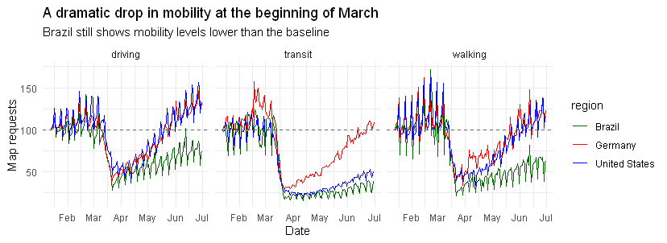

*Fig1 : A graph from the analysis shows a time series analysis for the 3 countries.*

We can observe from this graph that there is a transition from using public transportation to using private cars. what supports this result a research done by Juliane Anke, Angela Francke, Lisa-Marie Schaefer & Tibor Petzoldt impact in covid-19 in mobility behavior in Germany where Data showed a significant impact on mobility behavior, with a move away from public transportation and an increase in private vehicles[10].

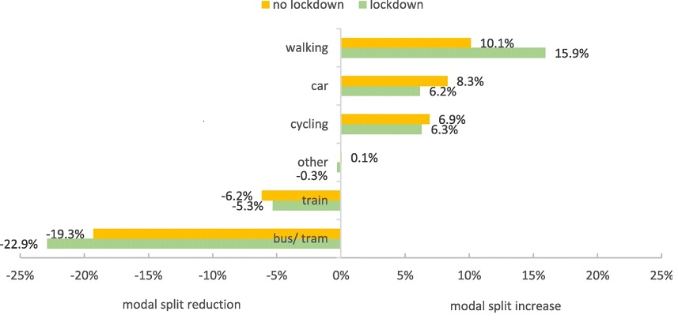

*Fig2 : Modal split differences (during-before COVID-19) for the lockdown and no lockdown group.*

*From: Impact of SARS-CoV-2 on the mobility behaviour in Germany Fig3[10].*

When comparing the two groups in Fig2, the lockdown group has a bigger jump in walking and lower utilization of public transportation, we can see this also in Fig1 especially in Brazil and the United States. There was a higher rise in car use without lockdown than with lockdown.

### Impact of COVID-19 on consumer behavior

The COVID-19 situation is influencing customer behavior and, as a result, marketing strategies. Consumers are being pushed to reconsider their objectives in life. Several trends have been recognized by Euromonitor International, including: Healthy life: It is becoming increasingly necessary to have a healthy lifestyle and practice healthy behaviors both inside and outside the home. Purchasing Reimagined: Many consumers are shifting to internet shopping as a result of social distancing[11].

### 6. Conclusion

From the analysis, we can see that Covid-19 has a great effect in mobility behavior a drop in map requests in Germany, Brazil, and the United States happened during the lockdown. Consequently, as a customer with the lack of movement and the closure of sports clubs, the priority will be health concerns, especially as it will improve the immune system to face any possible infection from the virus. An article supports this hypothesis which mentioned that the sudden emergence of the COVID-19 pandemic has had a beneficial effect on the worldwide sports gear industry’s growth. Due to the closure of gyms and fitness facilities during the lockdown, demand for home fitness equipment has surged. In addition, the outbreak has raised public awareness about the importance of maintaining personal health [11].

According to that, the Company can work in developing sensors in the wearable product to measure the heart rate or count the number of calories burned and we can pass an idea to the research and development department to see if it is possible to make a sensor which can measure the oxygen level in the blood which is helpful in diagnosing Covid-19 and monitoring Covid-19 mild cases at home[12]. If they succeed in that, the company will sell a lot.

we can also develop a program to tell the customers about the risky areas near them that which will raise an alarm and then no need to smartphones when the customers go jogging or running as some people prefer to leave their smartphones at home when they are doing some outdoor sports, and the product will be the magic solutions for this with its multifunctionality properties.

Thus, the product will be effective whether the person stays at home or doing outdoors or indoors sport, we can target all kind of customers. some will buy it for the reason to go outside counting their steps burning some calories. While the others will buy it because they may concern about checking the heart rate and blood pressure.

### 7.Data analysis using R

#### Load in the required R packages

```r
#include= F : runs the code, but does not show the results
library(readr)
library(tidyr)
library(dplyr)
library(ggplot2)
library(visdat) # to visualize the NA Values
```

#### Setting working Directory

```r
getwd()
```

```
## [1] "C:/Users/admin/Documents/data_vis_ss21"
```

```r
setwd("C:/Users/admin/Documents/data_vis_ss21")
```

#### Investigating the first six observations

```r
head(df)
```

```
## # A tibble: 6 x 176
##   geo_type region transportation_~ alternative_name `sub-region` country
##   <chr>    <chr>  <chr>            <chr>            <chr>        <chr>
## 1 country~ Alban~ driving          <NA>             <NA>         <NA>
## 2 country~ Alban~ walking          <NA>             <NA>         <NA>
## 3 country~ Argen~ driving          <NA>             <NA>         <NA>
## 4 country~ Argen~ walking          <NA>             <NA>         <NA>
## 5 country~ Austr~ driving          AU               <NA>         <NA>
## 6 country~ Austr~ transit          AU               <NA>         <NA>
## # ... with 170 more variables: `2020-01-13` <dbl>, `2020-01-14` <dbl>,
## #   `2020-01-15` <dbl>, `2020-01-16` <dbl>, `2020-01-17` <dbl>,
## #   `2020-01-18` <dbl>, `2020-01-19` <dbl>, `2020-01-20` <dbl>,
## #   `2020-01-21` <dbl>, `2020-01-22` <dbl>, `2020-01-23` <dbl>,
## #   `2020-01-24` <dbl>, `2020-01-25` <dbl>, `2020-01-26` <dbl>,
## #   `2020-01-27` <dbl>, `2020-01-28` <dbl>, `2020-01-29` <dbl>,
## #   `2020-01-30` <dbl>, `2020-01-31` <dbl>, `2020-02-01` <dbl>,
## #   `2020-02-02` <dbl>, `2020-02-03` <dbl>, `2020-02-04` <dbl>,
## #   `2020-02-05` <dbl>, `2020-02-06` <dbl>, `2020-02-07` <dbl>,
## #   `2020-02-08` <dbl>, `2020-02-09` <dbl>, `2020-02-10` <dbl>,
## #   `2020-02-11` <dbl>, `2020-02-12` <dbl>, `2020-02-13` <dbl>,
## #   `2020-02-14` <dbl>, `2020-02-15` <dbl>, `2020-02-16` <dbl>,
## #   `2020-02-17` <dbl>, `2020-02-18` <dbl>, `2020-02-19` <dbl>,
## #   `2020-02-20` <dbl>, `2020-02-21` <dbl>, `2020-02-22` <dbl>,
## #   `2020-02-23` <dbl>, `2020-02-24` <dbl>, `2020-02-25` <dbl>,
## #   `2020-02-26` <dbl>, `2020-02-27` <dbl>, `2020-02-28` <dbl>,
## #   `2020-02-29` <dbl>, `2020-03-01` <dbl>, `2020-03-02` <dbl>,
## #   `2020-03-03` <dbl>, `2020-03-04` <dbl>, `2020-03-05` <dbl>,
## #   `2020-03-06` <dbl>, `2020-03-07` <dbl>, `2020-03-08` <dbl>,
## #   `2020-03-09` <dbl>, `2020-03-10` <dbl>, `2020-03-11` <dbl>,
## #   `2020-03-12` <dbl>, `2020-03-13` <dbl>, `2020-03-14` <dbl>,
## #   `2020-03-15` <dbl>, `2020-03-16` <dbl>, `2020-03-17` <dbl>,
## #   `2020-03-18` <dbl>, `2020-03-19` <dbl>, `2020-03-20` <dbl>,
## #   `2020-03-21` <dbl>, `2020-03-22` <dbl>, `2020-03-23` <dbl>,
## #   `2020-03-24` <dbl>, `2020-03-25` <dbl>, `2020-03-26` <dbl>,
## #   `2020-03-27` <dbl>, `2020-03-28` <dbl>, `2020-03-29` <dbl>,
## #   `2020-03-30` <dbl>, `2020-03-31` <dbl>, `2020-04-01` <dbl>,
## #   `2020-04-02` <dbl>, `2020-04-03` <dbl>, `2020-04-04` <dbl>,
## #   `2020-04-05` <dbl>, `2020-04-06` <dbl>, `2020-04-07` <dbl>,
## #   `2020-04-08` <dbl>, `2020-04-09` <dbl>, `2020-04-10` <dbl>,
## #   `2020-04-11` <dbl>, `2020-04-12` <dbl>, `2020-04-13` <dbl>,
## #   `2020-04-14` <dbl>, `2020-04-15` <dbl>, `2020-04-16` <dbl>,
## #   `2020-04-17` <dbl>, `2020-04-18` <dbl>, `2020-04-19` <dbl>,
## #   `2020-04-20` <dbl>, `2020-04-21` <dbl>, ...
```

#### Quick view for our data

```r
View(df)
```

We can see observe that the data is not well-constructed. For this reason, we will begin our analysis with a crucial step which is data wrangling(data cleaning and transformation). Investigating the first six observations.

### Data Wrangling and cleaning

One crucial rule to follow while cleaning up our dataset is to put each variable (the date) inthe same column.

```r
mobility <- df %>%  gather(date, req_num ,"2020-01-13":"2020-06-30")
#with Pipe operator I pass the data to the gather function and make two coloumns which are the Date and the map requests count
```

#### Dealing with the missing values

Depending on our purpose of the analysis, we will deal with missing values, which are represented here by NA (not available). For example, we can take the mean of the variable and fill in the missing values with the result. However, we will work in specific regions. So, we don’t have to do that, instead, we will remove these values.

#### Check for the missing values in the “map requests count” column

```r
sum(is.na(mobility$req_num)) #is.na to check for missing values and with sum func we weill know the count
```

```
## [1] 13802
```

#### Visualizing missing values in our dataframe

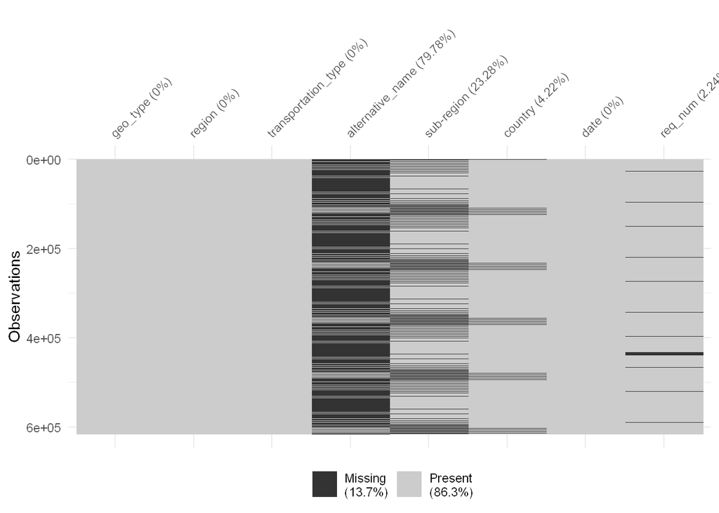

```r
vis_miss(mobility, warn_large_data = F) #from "visdat" library
```

#### Remove the rows with missing data from the “map requests count” column

```r
new_mob <- mobility %>% filter(!is.na(req_num))
#test again for NA values
sum(is.na(new_mob$req_num))
```

```
## [1] 0
```

#### Removing the the “alternative_name” column

Here in the dataset, the “alternative_name” column is not important in our analysis, so we gonna remove it.

```r
mobility <- new_mob %>% select(-alternative_name)
#with select function, we can choose specific columns. Here, I put - sign to remove this column from the data and store it in the same name of the object 'mobility which means I overwrited the data frame
head(mobility)
```

```
## # A tibble: 6 x 7
##   geo_type     region   transportation_ty~ `sub-region` country date     req_num
##   <chr>        <chr>    <chr>              <chr>        <chr>   <chr>      <dbl>
## 1 country/reg~ Albania  driving            <NA>         <NA>    2020-01~     100
## 2 country/reg~ Albania  walking            <NA>         <NA>    2020-01~     100
## 3 country/reg~ Argenti~ driving            <NA>         <NA>    2020-01~     100
## 4 country/reg~ Argenti~ walking            <NA>         <NA>    2020-01~     100
## 5 country/reg~ Austral~ driving            <NA>         <NA>    2020-01~     100
## 6 country/reg~ Austral~ transit            <NA>         <NA>    2020-01~     100
```

#### Investigate the remaining columns with colnames function

```r
colnames(mobility)
```

```
## [1] "geo_type"            "region"              "transportation_type"
## [4] "sub-region"          "country"             "date"
## [7] "req_num"
```

From the first blick, we can see that sub-region is a bad naming it is not good to use the ‘-’ minus sign because this may cause errors, instead, we gonna use underscore ’_’.

#### Rename the “sub-region” coloumn

```r
mobility <- rename(mobility, sub_region = "sub-region")
```

### Change position of “region” coloumn

```r
mobility <- mobility %>% relocate(region)
head(mobility)
```

```
## # A tibble: 6 x 7
##   region    geo_type      transportation_ty~ sub_region country date     req_num
##   <chr>     <chr>         <chr>              <chr>      <chr>   <chr>      <dbl>
## 1 Albania   country/regi~ driving            <NA>       <NA>    2020-01~     100
## 2 Albania   country/regi~ walking            <NA>       <NA>    2020-01~     100
## 3 Argentina country/regi~ driving            <NA>       <NA>    2020-01~     100
## 4 Argentina country/regi~ walking            <NA>       <NA>    2020-01~     100
## 5 Australia country/regi~ driving            <NA>       <NA>    2020-01~     100
## 6 Australia country/regi~ transit            <NA>       <NA>    2020-01~     100
```

### Investigate the structure of mobility

to examine the structure of the the dataset

```r
str(mobility)
```

```
## tibble[,7] [602,448 x 7] (S3: tbl_df/tbl/data.frame)
##  $ region             : chr [1:602448] "Albania" "Albania" "Argentina" "Argentina" ...
##  $ geo_type           : chr [1:602448] "country/region" "country/region" "country/region" "country/region" ...
##  $ transportation_type: chr [1:602448] "driving" "walking" "driving" "walking" ...
##  $ sub_region         : chr [1:602448] NA NA NA NA ...
##  $ country            : chr [1:602448] NA NA NA NA ...
##  $ date               : chr [1:602448] "2020-01-13" "2020-01-13" "2020-01-13" "2020-01-13" ...
##  $ req_num            : num [1:602448] 100 100 100 100 100 100 100 100 100 100 ...
```

We can see that this object is a data frame or tibble with 7 columns, and the data type of these variables is numeric for req_num and character for the rest. Therefore we have to handle this.

```r
class(mobility$region)
```

```
## [1] "character"
```

### Variables constraints

in this step, we will convert the variables data types to the proper one.

```r
mobility$geo_type <- as.factor(mobility$geo_type )
mobility$transportation_type <- as.factor(mobility$transportation_type)
mobility$date <- as.Date(mobility$date)
```

### Accessing components of the factor Transportation type

```r
levels(mobility$transportation_type)
```

```
## [1] "driving" "transit" "walking"
```

### Accessing components of the factor geo_type

```r
levels(mobility$geo_type)
```

```
## [1] "city"           "country/region" "county"         "sub-region"
```

### Summary statistics

For the numeric data, we want to know for example the central tendency (mean, median, and mode) also, to know the variability of our data like range, min, max (spread of the data) so, we can use the fivenum function or summary function

```r
summary(mobility$req_num)
```

```
##    Min. 1st Qu.  Median    Mean 3rd Qu.    Max.
##    2.43   77.26  103.22  106.52  127.77 1370.08
```

### Selecting US, Germany and Brazil

```r
#Using filter func from dplyr package with the logical operator or "|" to select our chosen countries
target_market <- filter(mobility, region == "Germany"| region == "United States" | region == "Brazil")
```

Investigate the first 6 rows

```r
head(target_market)
```

```
## # A tibble: 6 x 7
##   region  geo_type      transportation_ty~ sub_region country date       req_num
##   <chr>   <fct>         <fct>              <chr>      <chr>   <date>       <dbl>
## 1 Brazil  country/regi~ driving            <NA>       <NA>    2020-01-13     100
## 2 Brazil  country/regi~ transit            <NA>       <NA>    2020-01-13     100
## 3 Brazil  country/regi~ walking            <NA>       <NA>    2020-01-13     100
## 4 Germany country/regi~ driving            <NA>       <NA>    2020-01-13     100
## 5 Germany country/regi~ transit            <NA>       <NA>    2020-01-13     100
## 6 Germany country/regi~ walking            <NA>       <NA>    2020-01-13     100
```

#### Investigate the last 6 rows

```r
tail(target_market)
```

```
## # A tibble: 6 x 7
##   region     geo_type    transportation_t~ sub_region country date       req_num
##   <chr>      <fct>       <fct>             <chr>      <chr>   <date>       <dbl>
## 1 Germany    country/re~ driving           <NA>       <NA>    2020-06-30   130.
## 2 Germany    country/re~ transit           <NA>       <NA>    2020-06-30   109.
## 3 Germany    country/re~ walking           <NA>       <NA>    2020-06-30   122.
## 4 United St~ country/re~ driving           <NA>       <NA>    2020-06-30   132.
## 5 United St~ country/re~ transit           <NA>       <NA>    2020-06-30    49.8
## 6 United St~ country/re~ walking           <NA>       <NA>    2020-06-30   115.
```

#### Checking the data types of our data

```r
sapply(target_market, class)
```

```
##              region            geo_type transportation_type          sub_region
##         "character"            "factor"            "factor"         "character"
##             country                date             req_num
##         "character"              "Date"           "numeric"
```

so everything is ok, we can proceed our analysis

#### Summary for requests number of maps in the United States

```r
us <- filter(target_market, region == "United States")
summary(us$req_num)
```

```
##    Min. 1st Qu.  Median    Mean 3rd Qu.    Max.
##   19.06   49.81   91.94   81.58  107.54  162.45
```

#### Summary for requests number of maps in Germany

```r
ger <- filter(target_market, region == "Germany")
summary(ger$req_num)
```

```
##    Min. 1st Qu.  Median    Mean 3rd Qu.    Max.
##   29.10   65.80   96.98   89.41  110.61  161.49
```

##### Summary for requests number of maps in Brazil

```r
br <- filter(target_market, region == "Brazil")
summary(br$req_num)
```

```
##    Min. 1st Qu.  Median    Mean 3rd Qu.    Max.
##   15.71   36.61   60.34   65.84   97.97  171.31
```

For the categorical data, it is common to use frequency tables for example, we want to get the total count of observations that fall in the three countries to be sure that the comparison will be for the same number of observations

```r
table(target_market$region)
```

```
##
##        Brazil       Germany United States
##           504           504           504
```

An equal number of observations in the three countries will make our analysis is fair to compare.

```r
levels(us$transportation_type)
```

```
## [1] "driving" "transit" "walking"
```

#### Univariate qualitative analysis

#### Analysis of a single categorical variable

##### Frequency bar chart

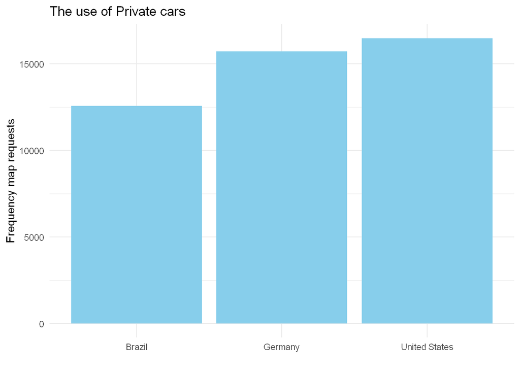

```r
filter(target_market,transportation_type=="driving") %>% ggplot( aes(x =region, y= req_num ))+
  geom_bar(stat = "identity", fill="skyblue")+
  labs(title ="The use of Private cars", y = "Frequency map requests", x =" ")+
  theme_minimal()
```

Using map requests service in driving is bigger in the US than Germany than Brazil, which makes sense due to the difference in the Gross domestic product (GDP) per capita.

##### The use of Map requests in Public Transport

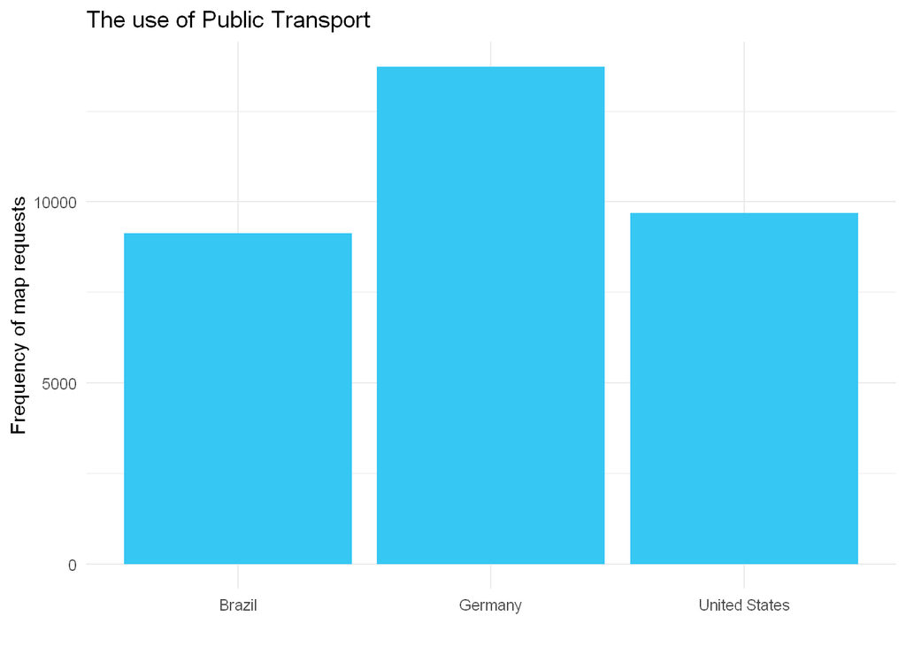

```r
filter(target_market,transportation_type=="transit") %>% ggplot( aes(x =region, y= req_num ))+
  geom_bar(stat = "identity", fill="#36C7F3")+
  labs(title ="The use of Public Transport", y = "Frequency of map requests", x="")+
  theme_minimal()
```

The use of Public transport in Germany is bigger than in Brazil and the US.

### Bringing all the three countries together for better comparison

We can use ggplot to see the behavior of different means of transport on the same graph. In the geom_bar() I will use the position parameter and assign dodge to it which allows us to make bar plots side by side to easily compare their variables.

In the geom_bar() I will use the position parameter and assign dodge to it which allows us to make bar plots side by side to easily compare their variables.

It is better to choose the theme minimal for better Visualisation not to distract our Audience, or obscure the graph with a lot of unnecessary data.

to improve the graph’s communication, it is good to choose a title of the graph which represents what the graph is telling us, or talking about, instead of just putting the x-axis vs y-axis. Also, scales have to be taken into consideration.

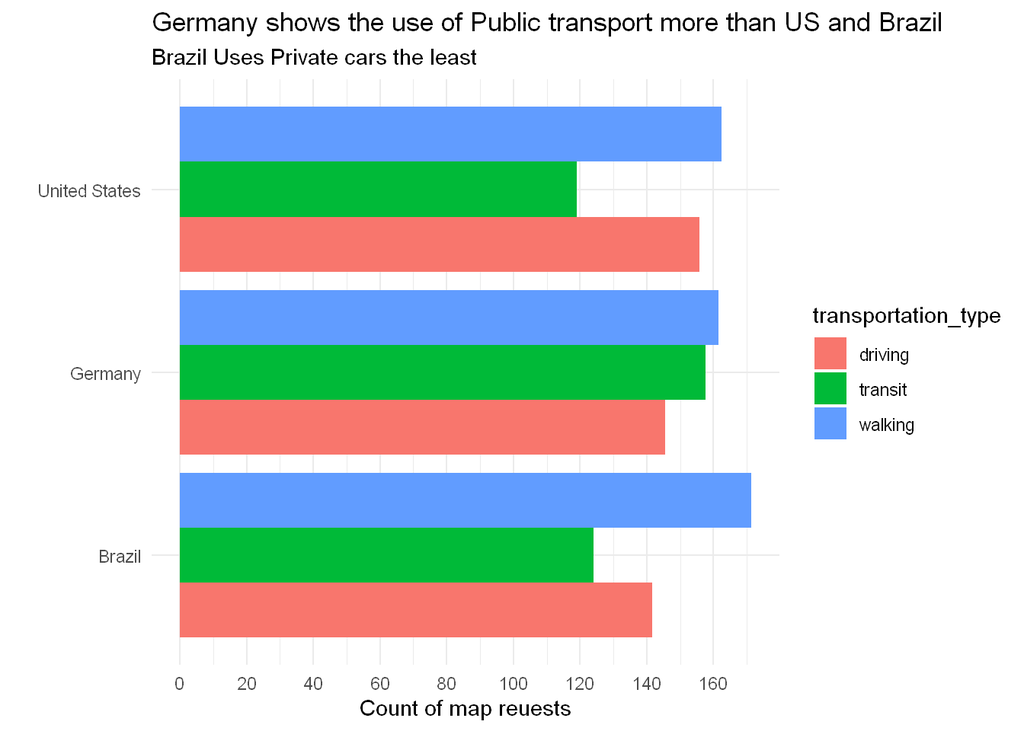

```r
ggplot(target_market,  aes(region, req_num ))+
  geom_bar(stat = "identity", aes(fill=transportation_type), position = "dodge")+ #use fill arg in aestestics enables us to choose the filled color depend on the region
  labs(title ="Germany shows the use of Public transport more than US and Brazil",
       subtitle="Brazil Uses Private cars the least ", y = "Count of map reuests", x ="")+
  scale_y_continuous(breaks = seq(0, 210, 20))+
  coord_flip()+
  theme_minimal()
```

we will see later the change of that over time

### Quantitative univariate analysis

### Analysis of a single numeric variable (Map requests Count)

the measure of the location of the data(central tendency), the spread of the data, shape.

#### Create a box plot of the number of requests of the maps

with a boxplot, we can see 5-number summary statistics for a single quantitative variable (number of map requests).

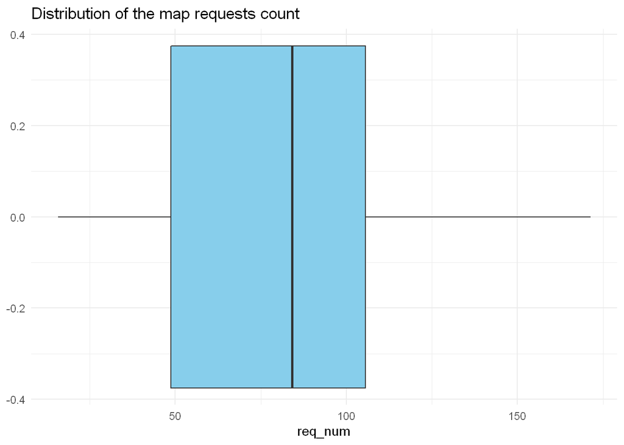

```r
ggplot(target_market, aes(x=req_num)) +
  geom_boxplot(fill="sky blue")+
  labs(title = "Distribution of the map requests count")+
  theme_minimal()
```

from the box plot we can see that, the min is around 15 and the max is around 171, Median is 84

### Comparison of the distribution of numeric value in the three regions

we can use fill parameter in aes() to visualize the difference of the distribution of the map requests between the three regions. for better visualizing, we will add the layer coordinate and view the box plot vertically.

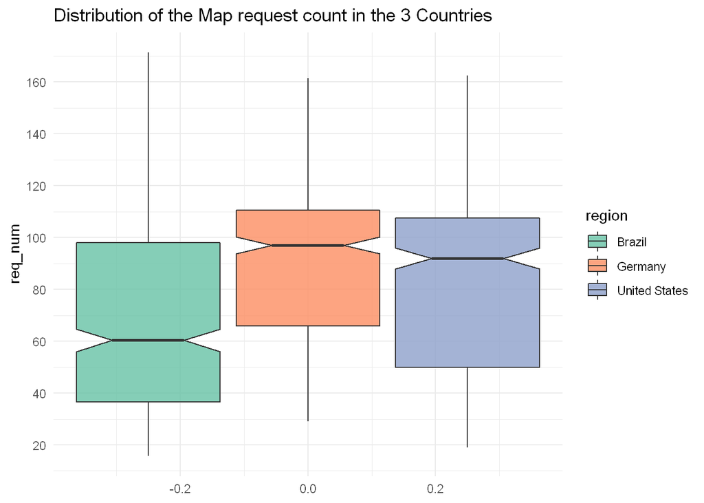

```r
ggplot(target_market, aes(x=req_num)) +
  geom_boxplot(notch = T, aes(fill=region),alpha=.8)+
  scale_fill_brewer(palette = "Set2") + # choose another color palette
  labs(title = "Distribution of the Map request count in the 3 Countries")+
  coord_flip()+
  scale_x_continuous(breaks = seq(0, 210, 20))+
  theme_minimal()
```

### Histogram

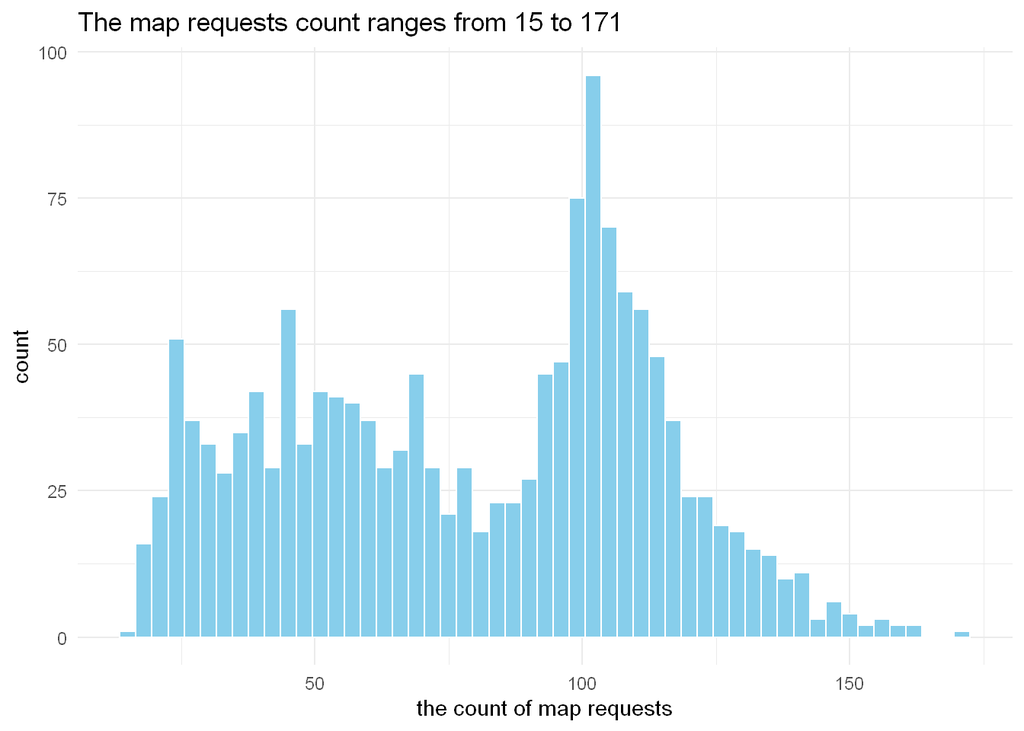

```r
ggplot(target_market, aes(x=req_num)) +
  geom_histogram(fill="skyblue", color = "white", binwidth = 3)+
  labs(title="The map requests count ranges from 15 to 171 ", x = "the count of map requests")+
  theme_minimal()
```

### Density plot

we can also use the density plot to visualize the distribution of the map requests

#### Finding the default value of bandwidth for req_num variable

```r
bw.nrd0(target_market$req_num)
```

```
## [1] 7.074668
```

to get more detail I will change this to two.

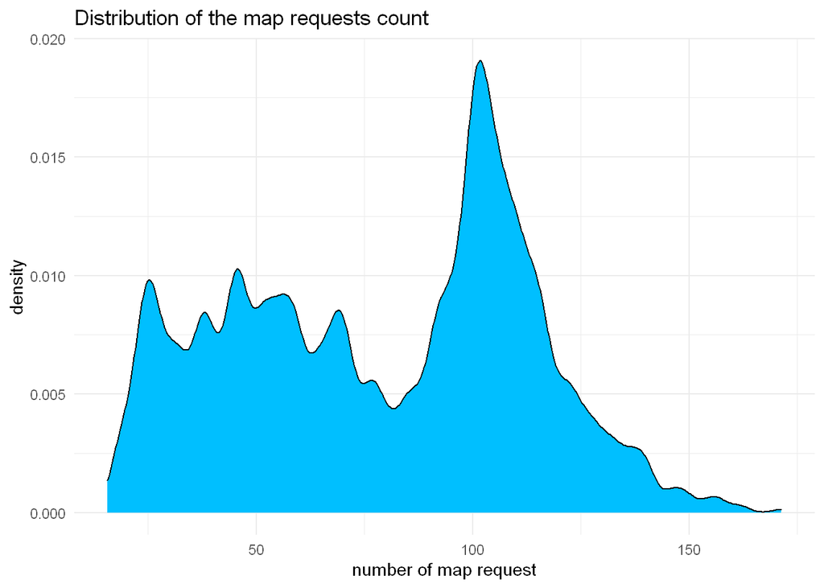

```r
ggplot(target_market, aes(x = req_num)) +
  geom_density(fill = "deepskyblue", bw = 2) +
  labs(title = "Distribution of the map requests count", x = "number of map request")+
  theme_minimal()
```

From the density plot, we can see that the most frequent score is 100 which makes sense because the number of the map requests before the pandemic and lockdown is 100 which is considered to be the baseline.

### Density plot for the three Countries

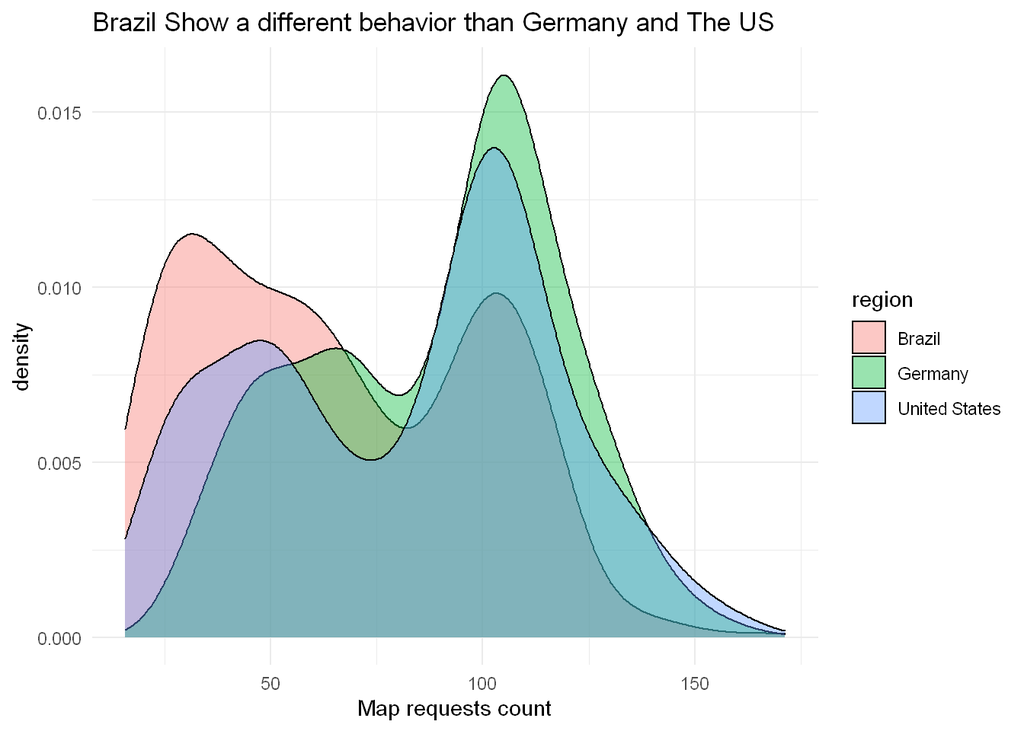

```r
ggplot(target_market, aes(x = req_num, fill = region)) +
  geom_density(alpha = 0.4) +
  labs(title = "Brazil Show a different behavior than Germany and The US", x= "Map requests count" )+
  theme_minimal()
```

### Scatter plot to see the diffrence between Germany and Brazil

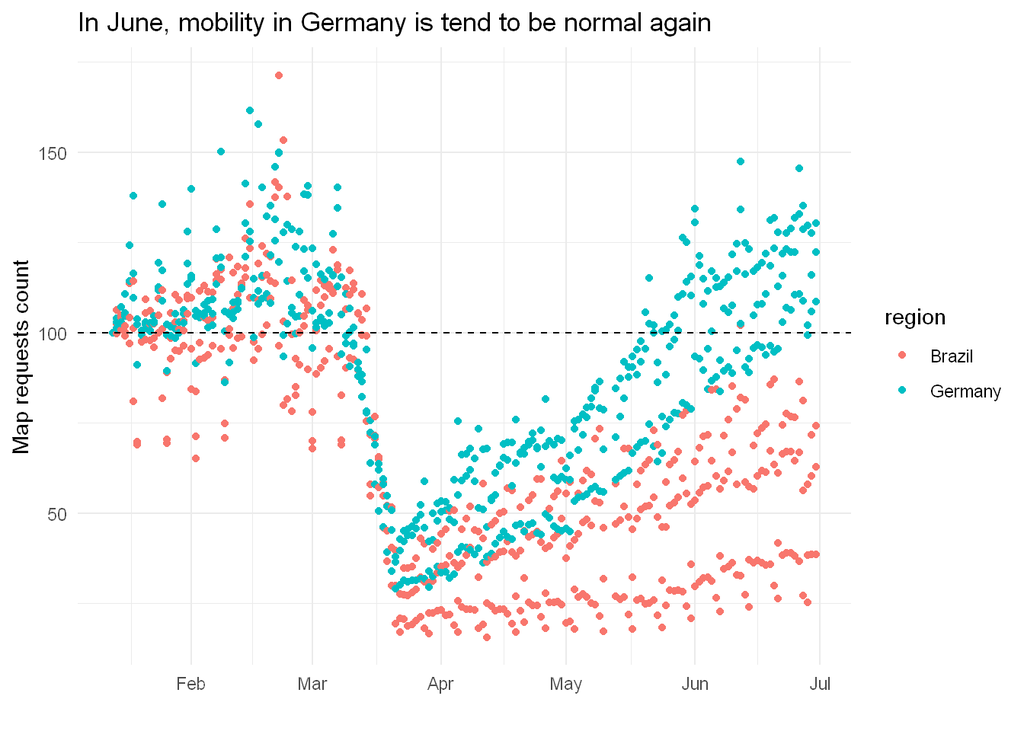

```r
ggplot(filter(target_market, region == "Brazil"| region=="Germany"), aes(x=date, y=req_num))+
  geom_point(aes(color = region))  +
  geom_hline(yintercept = 100, linetype = "dashed")+
  labs(title = "In June, mobility in Germany is tend to be normal again", x=" ", y="Map requests count" ) +
  theme_minimal()
```

from this scatter plot we can see that a dramatic decrease in the number of map requests in both countries. However, Germany was able to pass this period we can see a slight increase in mobility in June wherein brazil still in low levels.

## Time series Analysis

a common and better way to figure the change over time is the line graph. I have chosen the colors for the three countries manually to express the most dominant color that represents their flags.

### Mobility trends in Germany

In Germany, the map requests started to decrease in March and reached their lowest level in April during the lockdown to combat the spread of infection.

*Walking vs Public Transport*

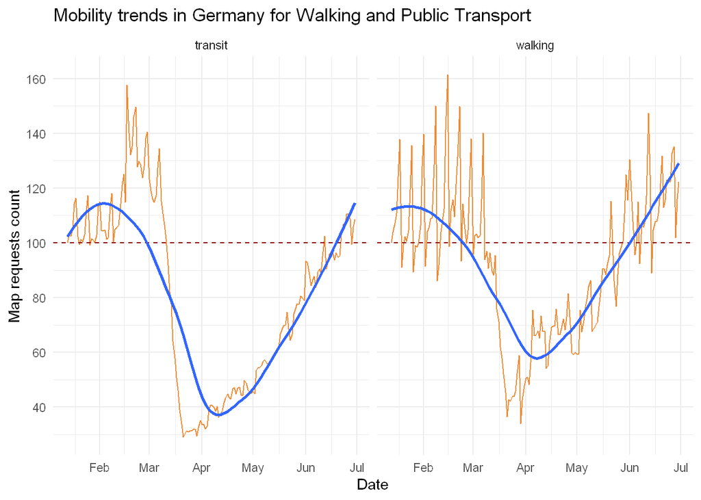

```r
ger_data <- filter(ger, transportation_type=="walking"|transportation_type=="transit")
ggplot(ger_data, aes(x = date, y = req_num)) +
  geom_line(color="#ED8C37") +
  geom_hline(yintercept = 100,color = "darkred", linetype = "dashed" )+
  labs(x = "Date",
    y = "Map requests count",
    title = "Mobility trends in Germany for Walking and Public Transport ")+
  scale_y_continuous(breaks = seq(0, 200, 20))+
  geom_smooth(se = FALSE) +
  facet_grid(. ~ transportation_type)+
  theme_minimal()
```

Slightly different when it compared with driving, which might because because lately some people are taking the precautions less seriously like the beginnig.

### Mobility trends in the United states

*Public Transport vs Walking*

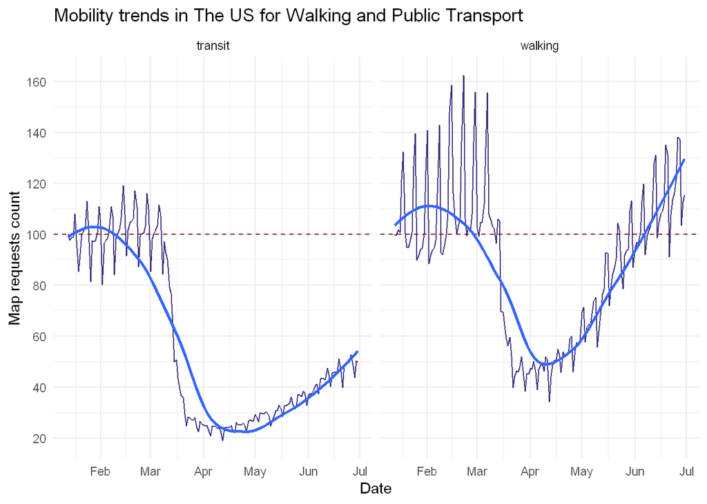

```r
us_data <- filter(us, transportation_type=="walking"|transportation_type=="transit")
ggplot(us_data, aes(x = date, y = req_num)) +
  geom_line(color="#3C3280") +
  geom_hline(yintercept = 100,color = "Darkred", linetype = "dashed" )+
  labs(x = "Date",
    y = "Map requests count",
    title = "Mobility trends in The US for Walking and Public Transport ")+
  scale_y_continuous(breaks = seq(0, 200, 20))+
  geom_smooth(se = FALSE) +
  facet_grid(. ~ transportation_type)+
  theme_minimal()
```

A sharp drop in the Public transport compared to walking.

### Mobility trends in Brazil

*Public Transport*

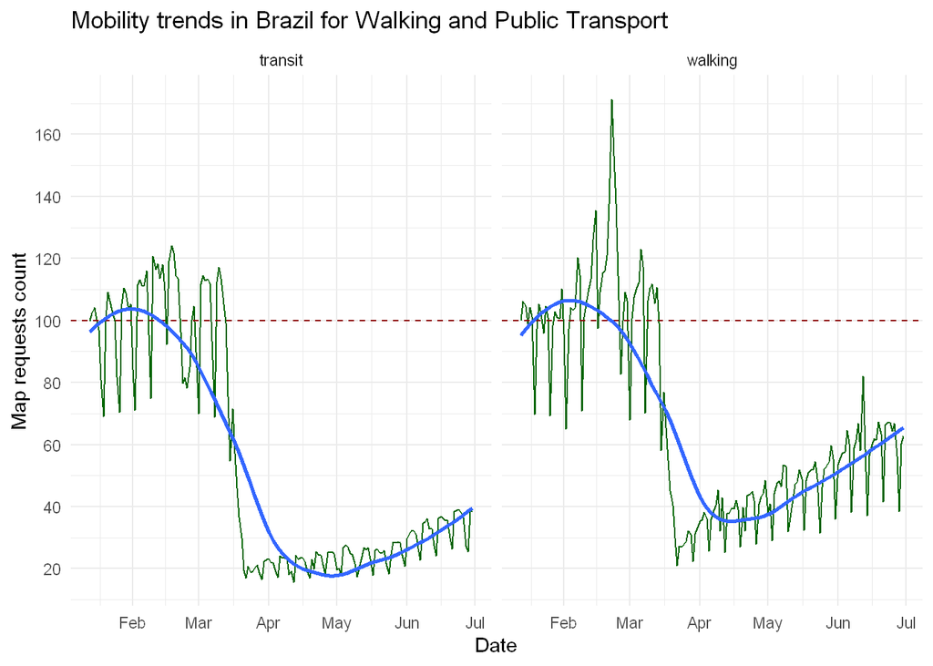

```r
br_data <- filter(br, transportation_type=="walking"|transportation_type=="transit")
ggplot(br_data, aes(x = date, y = req_num)) +
  geom_line(color="Darkgreen") +
  geom_hline(yintercept = 100,color = "darkred", linetype = "dashed" )+
  labs(x = "Date",
    y = "Map requests count",
    title = "Mobility trends in Brazil for Walking and Public Transport ")+
  scale_y_continuous(breaks = seq(0, 200, 20))+
  geom_smooth(se = FALSE) +
  facet_grid(. ~ transportation_type)+
  theme_minimal()
```

Here, we see a different behavior in brazil both walking and the use of public transport still at low levels till July.

### Compare all the three countries together

#### Driving

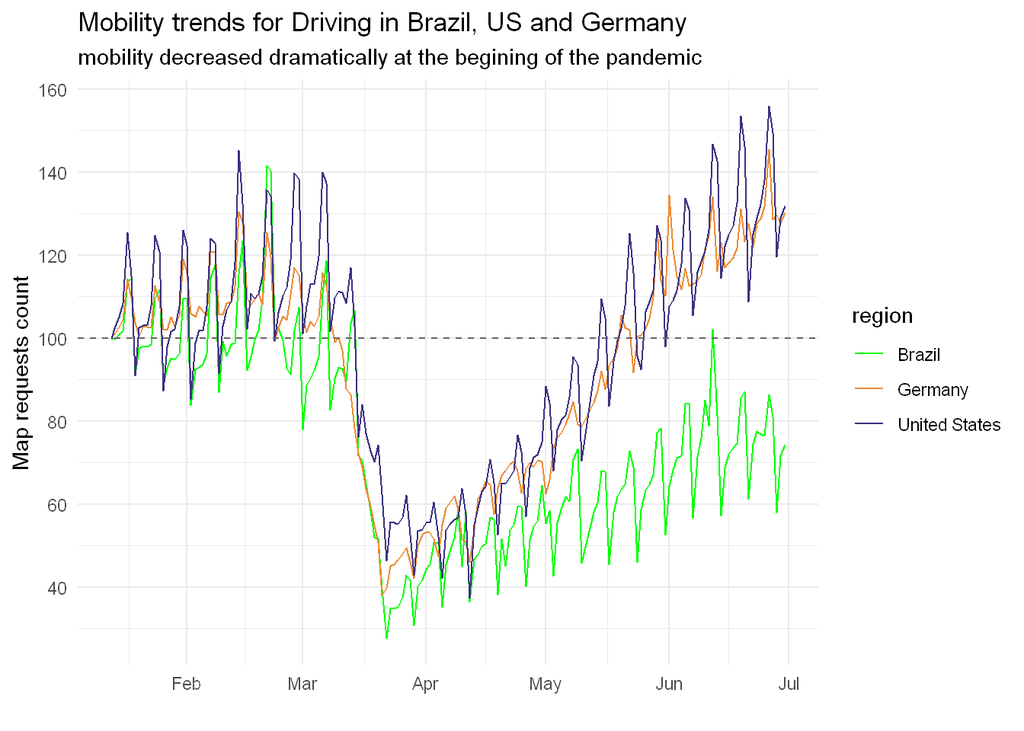

```r
drv <- filter(target_market,transportation_type=="driving")
ggplot(data = drv, aes(x = date, y = req_num )) +
  geom_line(aes(color =  region )) +
  geom_hline(yintercept = 100, color = "gray40", linetype = "dashed") +
     labs(x = " ",
    y = "Map requests count",
    title = "Mobility trends for Driving in Brazil, US and Germany ",
    subtitle = "mobility decreased dramatically at the begining of the pandemic")+
  scale_color_manual(values = c(Germany = "#ED8C37", Brazil = "green", "United States" ="#3C3280")) +
  scale_y_continuous(breaks = seq(0, 200, 20)) +
  theme_minimal()
```

The use of Private cars in Brazil is less than the US and Germany

#### Walking

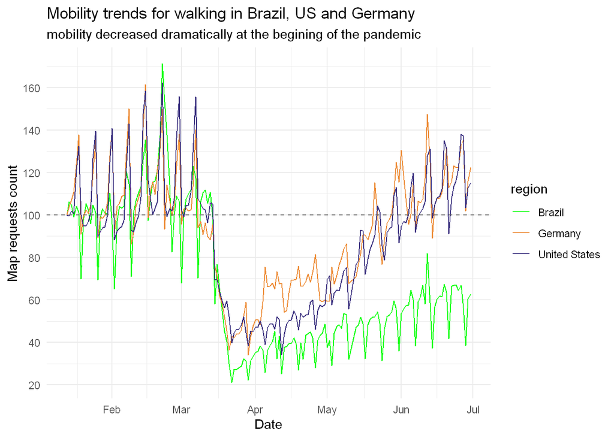

```r
#instead of putting the filtered data into a variable I choosed to use the pipe operator which cast it to the ggplot function
filter(target_market,transportation_type=="walking") %>% ggplot( aes(x = date, y = req_num )) +
  geom_line(aes(color =  region )) +
  geom_hline(yintercept = 100, color = "gray40", linetype = "dashed") +
  labs(x = "Date",
    y = "Map requests count",
    title = "Mobility trends for walking in Brazil, US and Germany ",
    subtitle = "mobility decreased dramatically at the begining of the pandemic")+
  scale_color_manual(values = c(Germany = "#ED8C37", Brazil = "green", "United States" ="#3C3280")) +
  scale_y_continuous(breaks = seq(0, 200, 20)) +
    theme_minimal()
```

Brazil Shows different behavior than Germany and the US.

#### Public Transport

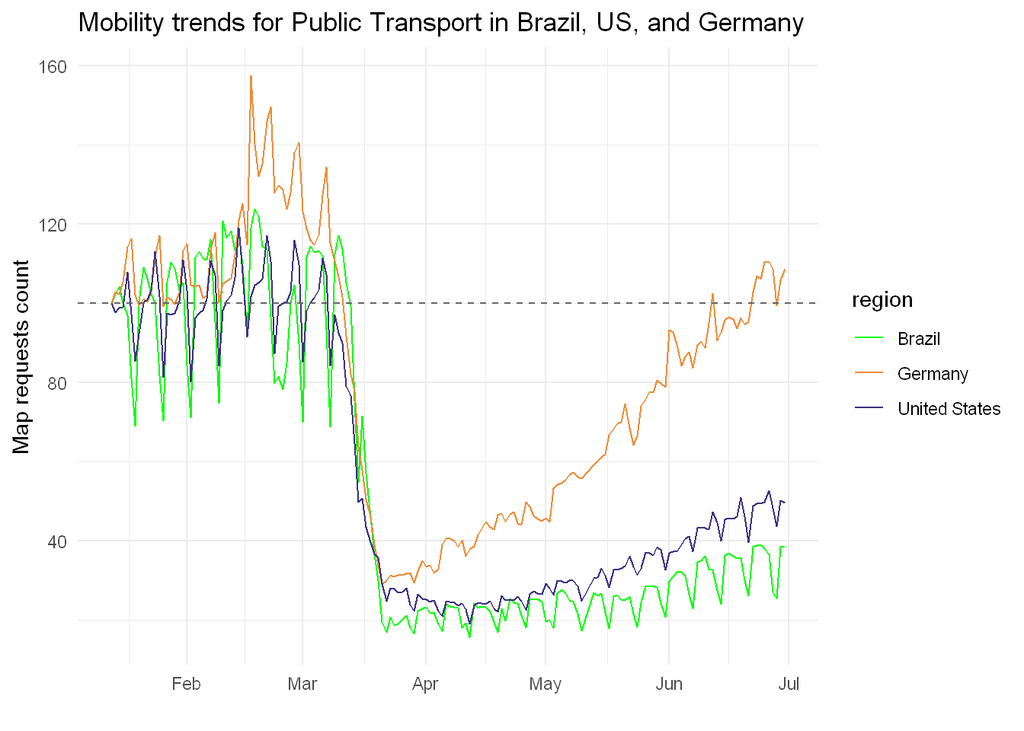

```r
filter(target_market,transportation_type=="transit") %>% ggplot( aes(x = date, y = req_num )) +
  geom_line(aes(color =  region )) +
  labs(x = " ",
    y = "Map requests count",
    title = "Mobility trends for Public Transport in Brazil, US, and Germany ")+
     scale_color_manual(values = c(Germany = "#ED8C37", Brazil = "green", "United States" ="#3C3280")) +
    geom_hline(yintercept = 100, color = "gray40", linetype = "dashed") +
    theme_minimal()
```

The use of public transport in brazil and united states show almost the same behavior

### Compare the 3 regions using facet layer

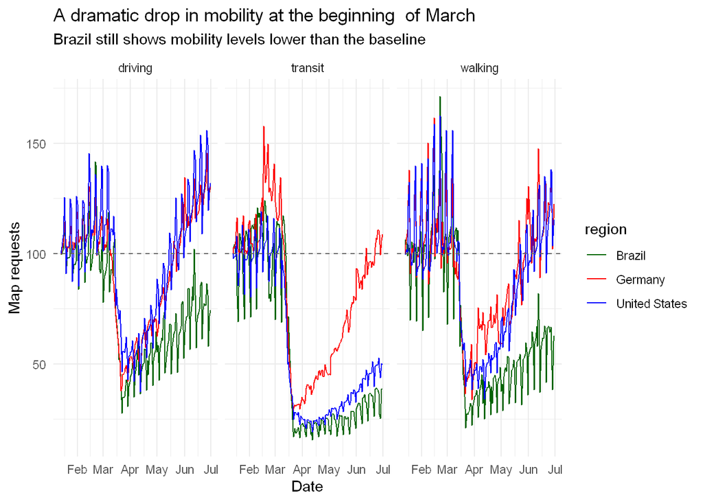

```r
ggplot(target_market, aes(date, req_num)) +
  geom_line(aes(color =  region )) +
  labs(x = "Date",
    y = "Map requests",
    title = "A dramatic drop in mobility at the beginning  of March ",
    subtitle = "Brazil still shows mobility levels lower than the baseline ")+
  geom_hline(yintercept = 100, color = "gray40", linetype = "dashed") + #base line
     scale_color_manual(values = c(Germany = "red", Brazil = "darkgreen", "United States" ="blue")) +
  facet_grid(. ~ transportation_type)+
    theme_minimal()
```

In terms of driving and walking, the United States and Germany Show similar behavior. However, when it comes to public transport the united states and brazil show similar behavior.

### 8.References

1. WHO/Europe. (2021). Coronavirus disease (COVID-19) pandemic. Retrieved June 20, 2021, from euro.who: https://www.euro.who.int/en/health-topics/health-emergencies/coronavirus-covid-19/novel-coronavirus-2019-ncov
2. Apple. (2020). Maps,Mobility Trends. from covid19.apple: https://covid19.apple.com/mobility.
3. Chan BKC. Data Analysis Using R Programming. Adv Exp Med Biol. 2018;1082:47-122. doi: 10.1007/978-3-319-93791-5_2. PMID: 30357717
4. F. Wu, M. Zhu, Q. Wang, X. Zhao, W. Chen and R. Maciejewski, “Spatial–temporal visualization of city-wide crowd movement,” Journal of Visualization, vol. 20, pp. 183-194, 2017.
5. T. Sobral, T. Galvão and J. Borges, “Visualization of urban mobility data from intelligent transportation systems,” Sensors, vol. 19, p. 332, 2019.
6. N. Oliver, E. Letouzé, H. Sterly, S. Delataille, M. De Nadai, B. Lepri, R. Lambiotte, R. Benjamins, C. Cattuto, V. Colizza and others, “Mobile phone data and COVID-19: Missing an opportunity?,” arXiv preprint arXiv:2003.12347, 2020.
7. P. Bonato, P. Cintia, F. Fabbri, D. Fadda, F. Giannotti, P. L. Lopalco, S. Mazzilli, M. Nanni, L. Pappalardo, D. Pedreschi and others, “Mobile phone data analytics against the COVID-19 epidemics in Italy: flow diversity and local job markets during the national lockdown,” arXiv preprint arXiv:2004.11278, 2020.
8. R Aurachman 2021 J. Phys.: Conf. Ser. 1833 012002
9. Slocat Partnership. (2020). Impact of COVID-19 on Mobility. Retrieved June 12, 2021, from slocat: https://slocat.net/covid-19-impact-mobility/
10. Anke, J., Francke, A., Schaefer, LM. et al. Impact of SARS-CoV-2 on the mobility behaviour in Germany. Eur. Transp. Res. Rev. 13, 10 (2021). https://doi.org/10.1186/s12544-021-00469-3
11. Research Dive. (2021). Covid-19 Positive Impact: Global Fitness Equipment Market. Retrieved June 18, 2021, from globenewswire: https://www.globenewswire.com/en/news-release/2021/05/20/2233394/0/en/Covid-19-Positive-Impact-Global-Fitness-Equipment-Market-Estimated-to-Beat-15-576-5-Million-Rising-at-4-0-CAGR-from-2020-to-2027-Exclusive-Report-Pages-181-by-Research-Dive.html
12. Greenhalgh T, Knight M, Inada-Kim M, Fulop N J, Leach J, Vindrola-Padros C et al. Remote management of covid-19 using home pulse oximetry and virtual ward support BMJ 2021; 372 :n677 doi:10.1136/bmj.n677